# Failed Genotypes Analysis

Dataset: big

29 October 2026

This script is for analysis of failed genotypes calls. It was mainly used when developing and troubleshooting the main MiniMap2 and ASP scripts. It makes a pretty graph where I tried to present amplicons with ASP primer alignment and coloured mismatches and SNP bases based on Phred quality scores. Also contains cool carousel like visuals to signify the amplicon is longer than whats presented.

Which genotype calls are checked is set with failed_genotypes_source (Bayesian or plain ASP calls). Only the reads that voted in the ASP run are used, so the run’s own threshold (errors or fraction) and SNP checks decide which reads are shown. The reads are aligned again only to find where the SNP, the mismatches and the anchor bases sit in each read.

## 1 Settings, paths and the primer panel

```r
suppressMessages({
  library(Biostrings)
  library(pwalign)
  library(dplyr)
  library(readr)
  library(readxl)
  library(ggplot2)
  library(scales)
  library(knitr)
})

# Settings come from the params block in the YAML header, this turns them into usable variables
invisible(list2env(params, envir = environment()))
# Uploading shared functions
source("Code/R_scripts/asp_functions.R", local = TRUE)


plot_font <- "Times New Roman"
theme_set(theme_minimal(base_family = plot_font))

timing_log <- list()

# Folder names are built with a shared function inside asp_functions.R, it gives a unique name based on changed settings for every run. If you use the same settings to rerun it again it gets overwritten.
run_names <- build_run_names(input_type, use_anchors, anchor_length, threshold_type, error_rate, min_score_fraction,
                             prior_type, prior_het_share, prior_population, prior_floor)
genotypes_dir <- file.path("Results", dataset_name, "Genotypes_results")
failed_genotypes_path <- switch(failed_genotypes_source,
                                asp_genotypes = file.path(genotypes_dir, run_names$asp_run_name, "all_barcodes_asp_genotypes.tsv"),
                                bayes_genotypes = file.path(genotypes_dir, run_names$bayes_run_name, "all_barcodes_base_mixture_genotypes_hierarchical.tsv"),
                                stop("failed_genotypes_source must be \"bayes_genotypes\" or \"asp_genotypes\""))

failed_reads_path <- file.path(genotypes_dir, run_names$asp_run_name, "all_barcodes_asp_reads.tsv")
reference_genotypes_path <- file.path("Data/Supporting_data/Reference_genotypes", paste0("genotypes_", dataset_name, ".tsv"))
for (needed_file in c(failed_genotypes_path, failed_reads_path, reference_genotypes_path)) {
  if (!file.exists(needed_file)) stop("file not found, run the earlier stages with the same settings first: ", needed_file)
}

# Output folders
failed_run_label <- basename(dirname(failed_genotypes_path))
out_dir_failed <- file.path("Results", dataset_name, "Graphics/Failed_genotypes_analysis", failed_run_label)
dir.create(out_dir_failed, showWarnings = FALSE, recursive = TRUE)

# Same primer panel preparation as in the ASP genotype pipeline
panel <- prepare_primer_panel(primer_panel_path, reference_path, input_type, use_anchors, anchor_length)
```

```
                   locus sta_overlap length_before_cut length_after_cut
            BICF2P878735           1                22               17
          BICF2S23033793           1                24               19
          BICF2S23758182           5                17                8
         BICF2G630320565           0                21               17
          BICF2S22912279           2                21               15
            BICF2P285168           0                24               20
          BICF2S23219794           1                21               16
 TIGRP2P116705_rs8955982           1                23               18
         BICF2G630703836           1                26               21
         BICF2G630580879           0                29               25
            BICF2P153324           1                21               16
         BICF2G630128194           1                25               20
          BICF2S23526960           1                24               19
          BICF2S23626182           1                20               15
           BICF2S2305942           0                18               14
           BICF2P1138616           2                26               20
 TIGRP2P247920_rs8757526           0                25               21
           BICF2P1262794           9                20                7
           BICF2P1060759           0                17               13
            BICF2P223300           2                21               15
            BICF2P363248           0                18               14
           BICF2P1165732           1                19               14
           BICF2P1448058           0                23               19
         BICF2G630165989           1                19               14
         BICF2G630126293           0                19               15
            BICF2P866415           0                25               21
         BICF2G630409723           2                23               17
         BICF2G630340139           0                25               21
         BICF2G630276750           0                23               19
            BICF2P239653           0                23               19
             BICF2P57528           0                18               14
            BICF2P400484           1                19               14
          BICF2S23225775           1                22               17
```

```r
# Barcode name mapping
barcode_map <- read_tsv(barcode_map_path, show_col_types = FALSE) %>%
  filter(dataset == dataset_name) %>%
  mutate(barcode_num = sub("^[A-Za-z]+", "", barcode))
```

## 2 Failed genotypes

Every sample x locus pair where the called genotype differs from the reference genotype. Pairs without a call or without a reference genotype are not miscalls and are left out.

```r
# Reads the full genotypes table and reference table
failed_calls <- read_tsv(failed_genotypes_path, show_col_types = FALSE, col_types = cols(genotype = col_character(), .default = col_guess())) %>%
  select(sample = barcode, locus, called_genotype = genotype)
reference_genotypes <- read_tsv(reference_genotypes_path, show_col_types = FALSE, col_types = cols(.default = col_character())) %>%
  select(sample = sample_id, locus, reference_genotype = genotype)

failed_markers <- failed_calls %>%
  inner_join(reference_genotypes, by = c("sample", "locus")) %>%
  filter(!is.na(called_genotype), !is.na(reference_genotype)) %>%
  mutate(across(c(called_genotype, reference_genotype), # Alphabetically sorted so all HT are the same
                ~ paste0(pmin(substr(.x, 1, 1), substr(.x, 2, 2)), pmax(substr(.x, 1, 1), substr(.x, 2, 2))))) %>%
  filter(called_genotype != reference_genotype) %>% # Filters for failed genotypes only
  arrange(locus, sample)

failed_counter_summary <- failed_markers %>%
  summarise(times_failed = n(),
            miscalls = paste0(sample, " (", called_genotype, " vs ", reference_genotype, ")", collapse = ", "), # e.g. W215294 (CT vs TT)
            .by = locus) %>%
  arrange(desc(times_failed))

write_tsv(failed_markers, file.path(out_dir_failed, "Failed_markers_detail.tsv"))
write_tsv(failed_counter_summary, file.path(out_dir_failed, "Failed_markers_summary.tsv"))

cat(sprintf("%s: %d miscalled sample x locus pairs at %d loci (%d samples)\n", failed_run_label, nrow(failed_markers),
            n_distinct(failed_markers$locus), n_distinct(failed_markers$sample)))
```

```
Identified_ASP_genotypes_unpadded_anchor3_errors0.08: 5 miscalled sample x locus pairs at 4 loci (5 samples)
```

```r
kable(failed_counter_summary, col.names = c("Locus", "Times failed", "Sample (called vs reference)"))
```

| Locus | Times failed | Sample (called vs reference) |
| --- | --- | --- |
| BICF2P223300 | 2 | W215207.r1 (CT vs CC), W215208.r1 (CT vs CC) |
| BICF2P57528 | 1 | W215214 (CT vs CC) |
| BICF2P878735 | 1 | W215220 (AG vs GG) |
| BICF2S2305942 | 1 | W215214.r1 (GT vs GG) |

## 3 Reads of the failed genotypes

The ASP reads table is filtered first: only reads of the miscalled pairs, and only reads that voted (called_allele not NA). Then each needed barcode’s .fastq file is read once and only those reads are kept.

```r
reads_start <- Sys.time()

# Reads the full reads table and joins or filters for failed called reads only
failed_voting_reads <- read_tsv(failed_reads_path, show_col_types = FALSE,
                                col_select = c(barcode, read_id, locus, direction, called_allele),
                                col_types = cols(.default = col_character())) %>% # alleles as text
  semi_join(failed_markers, by = c(barcode = "sample", "locus")) %>%
  filter(!is.na(called_allele))

# This loops reads every failed pair and its .fastq file and keeps only the reads that voted
fastq_read_tables <- list()
for (sample_id in unique(failed_voting_reads$barcode)) {
  barcode_number <- barcode_map$barcode_num[barcode_map$sample_id == sample_id] # proper barcode name
  if (length(barcode_number) != 1) {
    warning("no single barcode for sample ", sample_id, " in the barcode map, its reads are skipped")
    next
  }
  fastq_path <- identified_file_names_f(barcode_number) # builds the path
  if (!file.exists(fastq_path)) {
    warning("fastq not found, skipped: ", fastq_path)
    next
  }
  fastq_lines <- readLines(fastq_path)
  header_lines <- seq(1, length(fastq_lines), by = 4)
  fastq_read_ids <- sub("^@", "", sub(" .*$", "", fastq_lines[header_lines])) # grabs the reads id
  is_wanted <- fastq_read_ids %in% failed_voting_reads$read_id[failed_voting_reads$barcode == sample_id] # TRUE for this sample's voting reads
  wanted <- header_lines[is_wanted] # header line numbers
  fastq_read_tables[[sample_id]] <- data.frame(barcode = sample_id,
                                               read_id = fastq_read_ids[is_wanted], # read ID
                                               sequence = toupper(fastq_lines[wanted + 1]),
                                               quality = fastq_lines[wanted + 3])
}

failed_reads <- failed_voting_reads %>%
  inner_join(bind_rows(fastq_read_tables), by = c("barcode", "read_id"))
if (nrow(failed_reads) < nrow(failed_voting_reads)) {
  warning(nrow(failed_voting_reads) - nrow(failed_reads), " voting reads were not found in the .fastq files (files changed since the ASP run?)")
}

log_time(sprintf("read: voting reads of %d pairs (%d reads)", nrow(failed_markers), nrow(failed_reads)), reads_start)
```

```
[TIMING] read: voting reads of 5 pairs (42 reads): 7.25 sec
```

## 4 Read alignment

Every read of a pair is aligned to ASP1 and ASP2 in one batched call per primer, in the read’s own direction as in the ASP genotyping (unpadded reads are already turned forward, padded reverse reads are matched to the reverse complemented primers). The better of the two shows where the primer, the SNP, the mismatches and the anchor bases sit in the read. One table row per read, and one plot per pair with up to failed_max_reads_plotted reads (both called alleles take turns, so a minority allele is not left out).

```r
# It takes a read position ad returns  the base before and after it with Phred score
get_neighbour_context_string <- function(seq_string, qual_string, pos) {
  neighbours <- pos + c(-1, 0, 1) # neighbouring bases
  neighbours[neighbours < 1 | neighbours > nchar(seq_string)] <- NA # NA outside the read
  bases <- substring(seq_string, neighbours, neighbours) # gets the bases from the position
  qualities <- (utf8ToInt(qual_string) - 33)[neighbours] # gets the Phred score
  paste(sprintf("%s(%s)", bases, qualities), collapse = " | ") # for example T(12)|C(31)|C(29)
}

# This function translates alignemn ts columns into read positions. If there is a gap in the alignment it shifts the read positions and columns and I would get a wrong ending position. It returns a read position or NA if there is no base. It runs on every read in the aligment loop, it finds SNP position, mismatches, where the primers sits and quality lookup.
map_alignment_positions <- function(al) {
  is_read_base <- strsplit(as.character(pattern(al)), "")[[1]] != "-" # TRUE for a base and FALSE for a gap
  ifelse(is_read_base, start(pattern(al)) + cumsum(is_read_base) - 1, NA)
}
```

## 5 Amplicon plots of the failed genotypes

```r
### Plots are made per pair, each plot holds all the votings reads for one locus sample pair

# Plot layout variables
flank <- 7
taper_n <- 5
taper_widths <- c(0.82, 0.66, 0.50, 0.36, 0.24)
taper_text <- c(0.9, 0.78, 0.66, 0.54, 0.42) # smaller letter towards the end for carousel look

# Colour palette
quality_colours <- c("#A6513B", "#C9A66B", "#657359")
primer_colour <- "#D7C9BE"
flank_colour <- "#FAF6F3"
anchor_colour <- "#7C97AB"

read_result_tables <- list()
plot_paths <- character(0)

for (pair_index in seq_len(nrow(failed_markers))) {
  sample_id <- failed_markers$sample[pair_index] # basic read info
  locus_name <- failed_markers$locus[pair_index]
  pair_reads <- failed_reads %>% filter(barcode == sample_id, locus == locus_name)
  panel_row <- panel[panel$locus == locus_name, ]
  if (nrow(pair_reads) == 0 || nrow(panel_row) != 1) {
    cat(sprintf("%s / %s: no voting reads or no panel row, skipped\n", sample_id, locus_name))
    next
  }
  pair_start <- Sys.time()

  # Same alignments as in the genotyping function
  asp1 <- DNAString(panel_row$asp1_seq)
  asp2 <- DNAString(panel_row$asp2_seq)
  primer_list <- list(asp1, reverseComplement(asp1), asp2, reverseComplement(asp2))
  read_set <- DNAStringSet(pair_reads$sequence)
  primer_alignments <- lapply(primer_list, function(primer) pairwiseAlignment(read_set, primer, type = "overlap"))
  score_matrix <- do.call(cbind, lapply(primer_alignments, score)) # one row per read, one column per primer version
  read_is_reverse <- input_type == "padded" & pair_reads$direction == "reverse" # directional aware for padded and unapadded versions
  score_matrix[read_is_reverse, c(1, 3)] <- -Inf
  score_matrix[!read_is_reverse, c(2, 4)] <- -Inf
  best_index <- max.col(score_matrix, ties.method = "first")
  perfect_scores <- c(score(pairwiseAlignment(asp1, asp1, type = "overlap")), score(pairwiseAlignment(asp2, asp2, type = "overlap")))

  # Reads drawn in a plot, random order so different cases are visualized
  set.seed(pair_index)

  plotted_reads <- pair_reads %>%
    mutate(read_index = row_number(), random_rank = sample(n())) %>%
    group_by(called_allele) %>%
    mutate(rank_in_allele = rank(random_rank)) %>%
    ungroup() %>%
    arrange(rank_in_allele, called_allele) %>%
    slice_head(n = failed_max_reads_plotted) %>%
    pull(read_index)

  read_rows <- list()
  plot_rows <- list()
  for (k in seq_len(nrow(pair_reads))) {
    read_sequence <- pair_reads$sequence[k]
    read_quality <- pair_reads$quality[k]
    alignment <- primer_alignments[[best_index[k]]][k]
    read_chars <- strsplit(as.character(pattern(alignment)), "")[[1]] # separates reads alignment characters
    primer_chars <- strsplit(as.character(subject(alignment)), "")[[1]] # separates primers alignment characters
    real_pos <- map_alignment_positions(alignment) # helper function gets the real positions
    if (length(read_chars) == 0) next # no alignment

    is_asp1 <- best_index[k] %in% c(1, 2)
    is_rc <- best_index[k] %in% c(2, 4)
    snp_index <- if (is_rc) 1 else length(read_chars) # based RV or FWD it gets the SNP position (first or last)
    snp_position <- real_pos[snp_index]
    mismatch_index <- which(read_chars != primer_chars & !is.na(real_pos) & seq_along(read_chars) != snp_index) # separates SNP position from mismatches
    mismatch_position <- real_pos[mismatch_index]

    # anchor bases: the reference bases right after the SNP, read backwards from the SNP when the read matched the reverse complement
    anchor_bases <- strsplit(panel_row$anchor, "")[[1]]
    if (use_anchors && !is.na(panel_row$anchor) && length(anchor_bases) > 0 && !is.na(snp_position)) {
      anchor_positions <- if (is_rc) snp_position - seq_along(anchor_bases) else snp_position + seq_along(anchor_bases)
      expected_anchor <- if (is_rc) strsplit(as.character(complement(DNAString(panel_row$anchor))), "")[[1]] else anchor_bases
      inside_read <- anchor_positions >= 1 & anchor_positions <= nchar(read_sequence)
      anchor_positions <- anchor_positions[inside_read]
      expected_anchor <- expected_anchor[inside_read]
    } else {
      anchor_positions <- integer(0)
      expected_anchor <- character(0)
    }
    read_anchor <- if (length(anchor_positions) > 0) substring(read_sequence, anchor_positions, anchor_positions) else character(0)
    anchor_mismatch_position <- anchor_positions[read_anchor != expected_anchor]

    # Final results table
    read_rows[[length(read_rows) + 1]] <- data.frame(
      sample = sample_id,
      locus = locus_name,
      read_id = pair_reads$read_id[k],
      direction = pair_reads$direction[k],
      called_allele = pair_reads$called_allele[k],
      realigned_primer = if (is_asp1) "ASP1" else "ASP2",
      realigned_allele = if (is_asp1) panel_row$allele1 else panel_row$allele2,
      orientation = if (is_rc) "reverse complement" else "forward",
      score = round(score_matrix[k, best_index[k]], 2),
      perfect_match = score_matrix[k, best_index[k]] >= perfect_scores[if (is_asp1) 1 else 2] - 0.01,
      n_mismatches = length(mismatch_position),
      mismatch_contexts = paste(vapply(mismatch_position, get_neighbour_context_string, character(1), seq_string = read_sequence, qual_string = read_quality), collapse = "  ||  "),
      snp_context = get_neighbour_context_string(read_sequence, read_quality, snp_position),
      anchor_read = paste(read_anchor, collapse = ""),
      anchor_reference = paste(expected_anchor, collapse = ""),
      n_anchor_mismatches = length(anchor_mismatch_position))

    if (!k %in% plotted_reads) next

    primer_start <- min(real_pos, na.rm = TRUE)
    primer_end <- max(real_pos, na.rm = TRUE)
    normal_left <- primer_start - flank # Creates positions of starting flanking areas for graphs
    normal_right <- primer_end + flank
    seq_chars <- strsplit(read_sequence, "")[[1]]
    keep_positions <- seq(max(1, normal_left - taper_n), min(length(seq_chars), normal_right + taper_n)) #positions of bases shown on graphs
```

```r
    taper_step <- pmax(normal_left - keep_positions, keep_positions - normal_right, 0) # 0 inside the normal area, 1 to 5 going out into the taper
    widths <- c(1, taper_widths)[taper_step + 1]
    textmults <- c(1, taper_text)[taper_step + 1]
    tile_right_edge <- cumsum(widths) #cummulative sum gets you right edge 0.24, 0.36, 0.50  -> 0.24, 0.60, 1.10
    tile_left_edge <- tile_right_edge - widths # and this the left one 0, 0.24, 0.60
    tile_center <- (tile_left_edge + tile_right_edge) / 2 # the average then gives you the centre of the tile
    snp_local_index <- which(keep_positions == snp_position)
    snp_shift <- if (length(snp_local_index) == 1) tile_center[snp_local_index] else 0 #gets the tile centre of the SNP position
    tiles_centered_at_snp <- tile_center - snp_shift #snp position is now 0, every other is shifted

    base_quality <- (utf8ToInt(read_quality) - 33)[keep_positions] # Phred scores of the shown bases
    category <- case_when(
      keep_positions %in% snp_position ~ "SNP position",
      keep_positions %in% c(mismatch_position, anchor_mismatch_position) ~ "Mismatch",
      keep_positions %in% anchor_positions ~ "Anchor",
      keep_positions >= primer_start & keep_positions <= primer_end ~ "Primer",
      .default = "Flank")
    plot_row_number <- match(k, plotted_reads)

    plot_rows[[length(plot_rows) + 1]] <- data.frame( #saves all the formatting data of the read in one dataframe appended to a list
      y_label_for_reads = sprintf("%02d  voted %s | %s %s", plot_row_number, pair_reads$called_allele[k],
                                  if (is_asp1) "ASP1" else "ASP2", if (is_rc) "rc" else "fwd"),
      tiles_centered_at_snp = tiles_centered_at_snp,
      displayed_width = widths,
      text_mult = textmults,
      base = seq_chars[keep_positions],
      quality = base_quality,
      category = category)
  }

  log_time(sprintf("align: %s / %s (%d reads)", sample_id, locus_name, nrow(pair_reads)), pair_start)

  read_result_tables[[paste(sample_id, locus_name)]] <- bind_rows(read_rows)
  if (length(plot_rows) == 0) next # no read of this pair could be drawn
  plot_data <- bind_rows(plot_rows) #binds all the rows

  plot_data$y_label_for_reads <- factor(plot_data$y_label_for_reads, levels = rev(sort(unique(plot_data$y_label_for_reads)))) # ggplot draws y factors from the bottom up, reversed so read 01 is on top
  flank_tiles <- plot_data %>% filter(category == "Flank")
  primer_tiles <- plot_data %>% filter(category == "Primer")
  anchor_tiles <- plot_data %>% filter(category == "Anchor")
  quality_tiles <- plot_data %>% filter(category %in% c("SNP position", "Mismatch"))
  snp_tiles <- plot_data %>% filter(category == "SNP position")
  n_reads_plotted <- length(unique(plot_data$y_label_for_reads))

  # legend squares for the tile colours, the anchor only when anchors are used
  region_keys <- c("Primer", "Flank (amplicon continues)", if (use_anchors) "Anchor", "SNP base (outlined)")
  region_fills <- c(primer_colour, flank_colour, if (use_anchors) anchor_colour, "white")
  region_outlines <- c(primer_colour, "grey80", if (use_anchors) anchor_colour, "grey10")

  amplicon_plot <- ggplot(plot_data, aes(x = tiles_centered_at_snp, y = y_label_for_reads)) +
    geom_tile(data = flank_tiles, aes(width = displayed_width, height = 0.75 + 0.1 * text_mult), fill = flank_colour, color = "white", linewidth = 0.3) +
    geom_text(data = flank_tiles, aes(label = base, size = 1.7 * text_mult), color = "grey55") +
    geom_tile(data = primer_tiles, aes(width = displayed_width), fill = primer_colour, color = "white", linewidth = 0.4, height = 0.9) +
    geom_text(data = primer_tiles, aes(label = base), size = 2.3, fontface = "bold", color = "grey15") +
    geom_tile(data = anchor_tiles, aes(width = displayed_width), fill = anchor_colour, alpha = 0.8, color = "white", linewidth = 0.4, height = 0.9) +
    geom_text(data = anchor_tiles, aes(label = base), size = 2.3, fontface = "bold", color = "white") +
    geom_tile(data = quality_tiles, aes(fill = quality, width = displayed_width), alpha = 0.8, color = "white", linewidth = 0.4, height = 0.9) +
    geom_tile(data = snp_tiles, aes(width = displayed_width), fill = NA, color = "grey10", linewidth = 0.5, height = 0.9) + # outline marks the SNP base
    geom_text(data = quality_tiles, aes(label = base), size = 2.5, fontface = "bold", color = "grey10") +
    geom_point(data = transform(plot_data[rep(1, length(region_keys)), ], region = factor(region_keys, levels = region_keys)),
               aes(shape = region), alpha = 0) +
    scale_shape_manual(values = setNames(rep(22, length(region_keys)), region_keys), name = NULL) +
    guides(shape = guide_legend(position = "bottom", nrow = 1,
                                override.aes = list(alpha = 1, size = 4, stroke = 0.6, fill = region_fills, colour = region_outlines))) +
    scale_fill_gradientn(colors = quality_colours, limits = c(0, 25), oob = squish, name = "Phred quality\n(SNP and\nmismatches)") +
    scale_size_identity() +
    labs(title = sprintf("%s - %s", sample_id, locus_name),
         subtitle = sprintf("Called %s, reference %s - %d of %d voting reads shown", failed_markers$called_genotype[pair_index],
                            failed_markers$reference_genotype[pair_index], n_reads_plotted, nrow(pair_reads)),
         x = NULL, y = NULL) +
    theme_minimal(base_size = 8, base_family = plot_font) +
    theme(panel.grid = element_blank(),
          axis.text.y = element_text(size = 6.5, hjust = 1, family = "mono"),
          axis.text.x = element_blank(),
          plot.title = element_text(hjust = 0.5, face = "bold"),
          plot.subtitle = element_text(hjust = 0.5),
          legend.key.height = unit(0.4, "cm"),
          legend.key.width = unit(0.3, "cm"))

  plot_file <- file.path(out_dir_failed, sprintf("%s_%s_amplicon_quality", sample_id, locus_name))
  plot_height <- 1.3 + 0.24 * n_reads_plotted
  plot_start <- Sys.time()

  ggsave(paste0(plot_file, ".png"), amplicon_plot, width = 8.27, height = plot_height, dpi = 300, bg = "white")
  ggsave(paste0(plot_file, ".pdf"), amplicon_plot, width = 8.27, height = plot_height, device = cairo_pdf)
  log_time(sprintf("ggsave: %s / %s (%d reads plotted)", sample_id, locus_name, n_reads_plotted), plot_start)
  plot_paths <- c(plot_paths, paste0(plot_file, ".png"))
}
```

```r
failed_read_results <- bind_rows(read_result_tables)
write_tsv(failed_read_results, file.path(out_dir_failed, "Failed_marker_troubleshoot_detail.tsv"))

# one row per pair: how the voting reads split and how often the realignment agrees with the run's vote
failed_pair_summary <- failed_read_results %>%
  group_by(sample, locus) %>%
  summarise(voting_reads = n(),
            votes = paste(names(table(called_allele)), table(called_allele), sep = ":", collapse = "/"),
            realignment_agrees = sum(realigned_allele == called_allele),
            mean_mismatches = round(mean(n_mismatches), 2),
            reads_with_anchor_mismatch = sum(n_anchor_mismatches > 0),
            .groups = "drop") %>%
  left_join(failed_markers, by = c("sample", "locus"))
write_tsv(failed_pair_summary, file.path(out_dir_failed, "Failed_pairs_read_summary.tsv"))
kable(failed_pair_summary, col.names = c("Sample", "Locus", "Voting reads", "Votes", "Realignment agrees",
                                         "Mean mismatches", "Reads with anchor mismatch", "Called", "Reference"))
```

```
[TIMING] align: W215207.r1 / BICF2P223300 (7 reads): 0.69 sec
[TIMING] ggsave: W215207.r1 / BICF2P223300 (7 reads plotted): 0.47 sec
[TIMING] align: W215208.r1 / BICF2P223300 (10 reads): 0.43 sec
[TIMING] ggsave: W215208.r1 / BICF2P223300 (10 reads plotted): 0.32 sec
[TIMING] align: W215214 / BICF2P57528 (13 reads): 0.47 sec
[TIMING] ggsave: W215214 / BICF2P57528 (13 reads plotted): 0.51 sec
[TIMING] align: W215220 / BICF2P878735 (3 reads): 0.35 sec
[TIMING] ggsave: W215220 / BICF2P878735 (3 reads plotted): 0.28 sec
[TIMING] align: W215214.r1 / BICF2S2305942 (9 reads): 0.46 sec
[TIMING] ggsave: W215214.r1 / BICF2S2305942 (9 reads plotted): 0.33 sec
```

| Sample | Locus | Voting reads | Votes | Realignment agrees | Mean mismatches | Reads with anchor mismatch | Called | Reference |
| --- | --- | --- | --- | --- | --- | --- | --- | --- |
| W215207.r1 | BICF2P223300 | 7 | C:4/T:3 | 7 | 0.14 | 1 | CT | CC |
| W215208.r1 | BICF2P223300 | 10 | C:4/T:6 | 10 | 0.50 | 0 | CT | CC |
| W215214 | BICF2P57528 | 13 | C:10/T:3 | 13 | 0.23 | 1 | CT | CC |
| W215214.r1 | BICF2S2305942 | 9 | G:6/T:3 | 9 | 0.22 | 0 | GT | GG |
| W215220 | BICF2P878735 | 3 | A:1/G:2 | 3 | 0.67 | 0 | AG | GG |

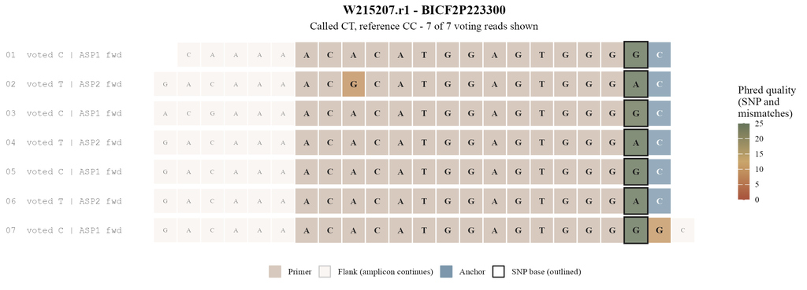

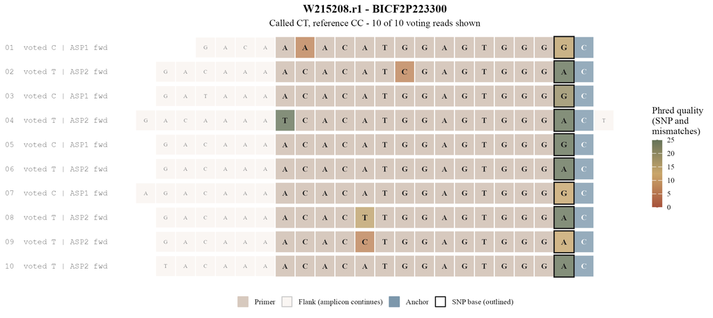

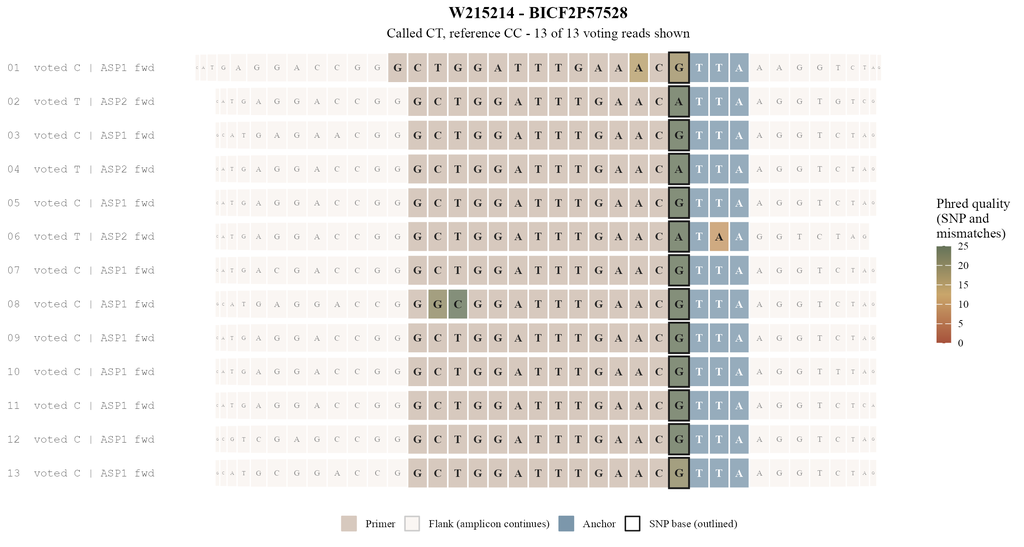

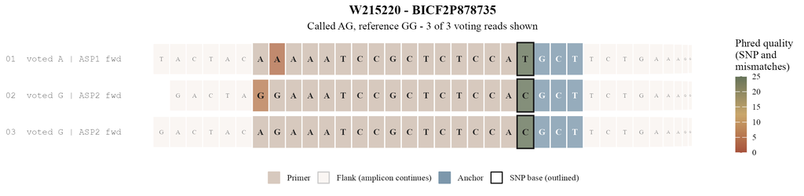

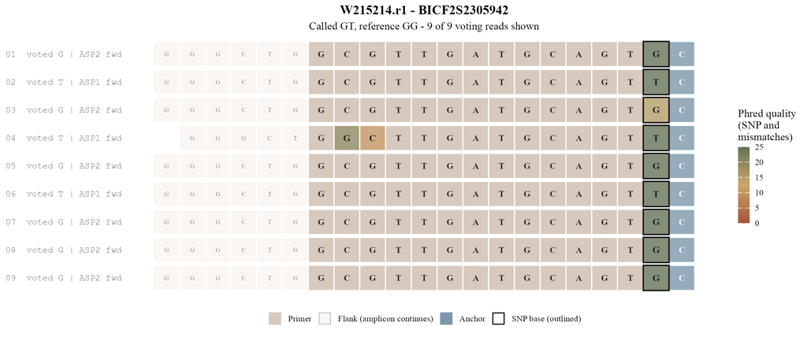

```r
# Renders the plots inside the html, this is used because plots are made in a loop a can be of varying heights, depending on the number of miscalled reads
include_graphics(normalizePath(plot_paths), rel_path = FALSE)
```

## 6 Timing summary

```r
timing_summary <- bind_rows(timing_log)
if (nrow(timing_summary) > 0) {
  timing_summary$seconds <- round(timing_summary$seconds, 2)
  write_tsv(timing_summary, file.path(out_dir_failed, "timing_breakdown_failed_analysis.tsv"))
  timing_summary$step_type <- sub(":.*", "", timing_summary$step)
  aggregate(seconds ~ step_type, data = timing_summary, sum)
}
```

| step_type | seconds |
| --- | --- |
| align | 2.40 |
| ggsave | 1.91 |
| read | 7.25 |